# Introduction to R

[figure not shown]

## Introduction to R Instructor: Mehdi Rezvandehy

Introduction

R is an interpreted programming language for statistical computing and graphics supported by the [R Foundation](https://www.r-project.org/foundation/). It is widely used among statisticians and data miners for developing statistical software and data analysis. This page presents how to run R in [Jupyter Notebook](https://jupyter.org/) for better documentation, reproducibility and sharing the results. Python and Jupyter Notebook should be already installed.

# Run R on Jupyter Notebook

The distributions of R packages (Linux, Mac OS X, and Windows) are available at the [Comprehensive R Archive Network](https://cloud.r-project.org/index.html). Download R for Windows, macOS or Linux and then install it on your machine.

[figure not shown]

## Install R kernel for Jupyter Notebook

Jupyter Notebook has kernels which are processes that run interactive code in a particular programming language and return output to the user. [IRkernel](https://irkernel.github.io/) is an **R kernel** for Jupyter Notebook.

IRkernel packages can be installed by running to the following command in an R console:

`install.packages('IRkernel')`

[figure not shown]

## Kernel Available on Jupyter Notebook

Then, you will have to make Jupyter see the newly installed R kernel by installing a kernel spec. To install system-wide, set user to False in the **installspec** command:

`IRkernel::installspec(user = FALSE)`

[figure not shown]

## Launch Jupyter Notebook with R

Now, the Jupyter Notebook supports both Python 3 and R programming languages. Type **jupyter notebook** in the anaconda console and press enter to pop up empty workspace. Now create a new R notebook by clicking on the New button and selecting R.

[figure not shown]

## Install R Packages and Load in Jupyter Notebook

R packages should be installed in R console. For example, for installing “ggplot2“ type:

`install.packages("ggplot2")`

Then you can load the package in Jupyter Notebook and plot and embedded image as below:

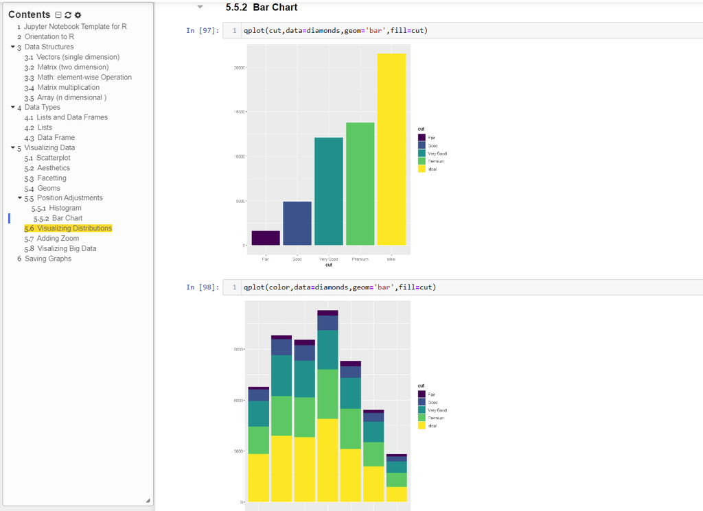

## Add Table of Content on Jupyter Notebook

First, install `jupyter_nbextensions_configurator` by typing this command in the anaconda console and press enter:

`pip install jupyter_nbextensions_configurator`

Then, type **jupyter notebook** in the anaconda console

[figure not shown]

Finally, click on Table of contents icon to generate table of contents

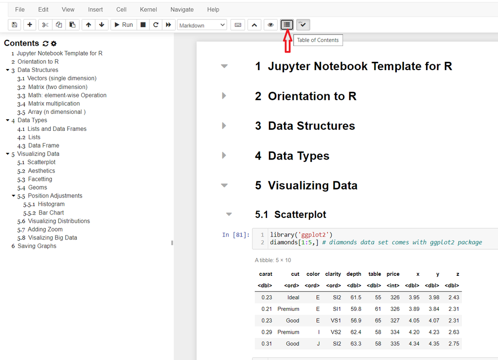

Table of Contents can be generated on first cell. First click on Contents on top left figure below (**Step 1**) and then tick *Add notebook TOC* cell (**Step 2**) :

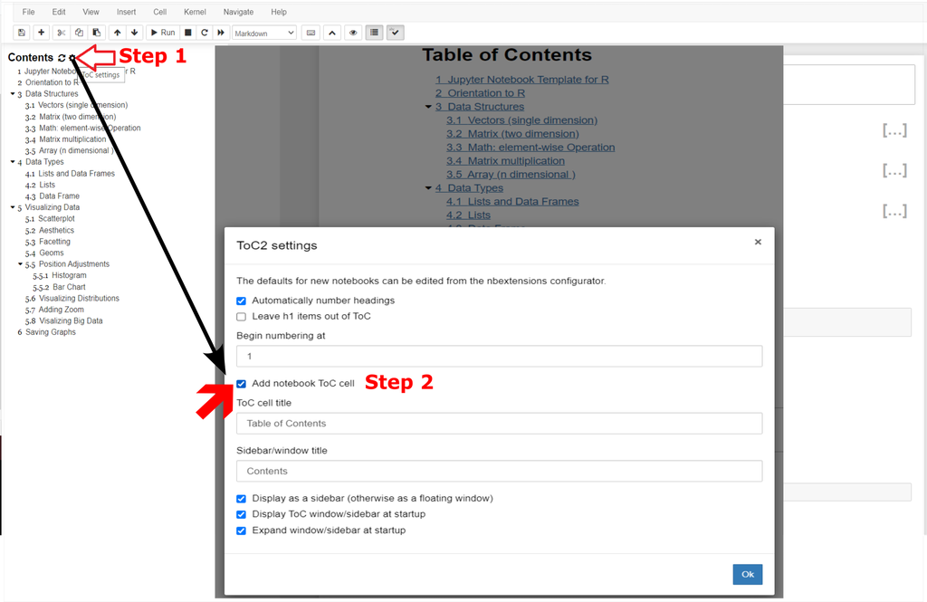

# Orientation to R

```r
print("Hello World", quote=FALSE)
```

```
[1] Hello World
```

```r
a<- 1  # a=1
b<- 2  # b=2
```

```r
a+b
```

3

```r
round(3.1415)
```

3

```r
factorial(3)  # 3!=3*2*1
```

6

```r
sqrt(14)  # square root
```

3.74165738677394

```r
factorial (round(2.0015)+1)
```

6

```r
log10(1000)+log10(100)
```

5

```r
pi
```

3.14159265358979

# Data Structures

```r
# Load WorldPhones data set
WorldPhones  # Number of phone numbers
```

A matrix: 7 × 7 of type dbl

|  | N.Amer | Europe | Asia | S.Amer | Oceania | Africa | Mid.Amer |
| --- | --- | --- | --- | --- | --- | --- | --- |
| 1951 | 45939 | 21574 | 2876 | 1815 | 1646 | 89 | 555 |
| 1956 | 60423 | 29990 | 4708 | 2568 | 2366 | 1411 | 733 |
| 1957 | 64721 | 32510 | 5230 | 2695 | 2526 | 1546 | 773 |
| 1958 | 68484 | 35218 | 6662 | 2845 | 2691 | 1663 | 836 |
| 1959 | 71799 | 37598 | 6856 | 3000 | 2868 | 1769 | 911 |
| 1960 | 76036 | 40341 | 8220 | 3145 | 3054 | 1905 | 1008 |
| 1961 | 79831 | 43173 | 9053 | 3338 | 3224 | 2005 | 1076 |

## Vectors (single dimension)

```r
vec <- c(1,2,3,10,100) # c create vector
vec
```

1. 1

2. 2

3. 3

4. 10

5. 100

## Matrix (two dimension)

```r
mat <- matrix (c(1,2,3,4,5,6),nrow=2)
mat
```

A matrix: 2 × 3 of type dbl

| 1 | 3 | 5 |
| --- | --- | --- |
| 2 | 4 | 6 |

## Math: element-wise Operation

```r
vec+4
```

1. 5

2. 6

3. 7

4. 14

5. 104

```r
vec*4
```

1. 4

2. 8

3. 12

4. 40

5. 400

```r
vec*vec
```

1. 1

2. 4

3. 9

4. 100

5. 10000

## Matrix multiplication

```r
vec %*% vec # inner multipication
```

A matrix: 1 × 1 of type dbl

| 10114 |
| --- |

```r
vec%o% vec  # outer multipication
```

A matrix: 5 × 5 of type dbl

| 1 | 2 | 3 | 10 | 100 |
| --- | --- | --- | --- | --- |
| 2 | 4 | 6 | 20 | 200 |
| 3 | 6 | 9 | 30 | 300 |
| 10 | 20 | 30 | 100 | 1000 |
| 100 | 200 | 300 | 1000 | 10000 |

```r
# Transpose matrix by t
mat
```

A matrix: 2 × 3 of type dbl

| 1 | 3 | 5 |
| --- | --- | --- |
| 2 | 4 | 6 |

```r
t(mat)
```

A matrix: 3 × 2 of type dbl

| 1 | 2 |
| --- | --- |
| 3 | 4 |
| 5 | 6 |

## Array (n dimensional )

```r
array(c(1,2,3,4,5,6), dim=c(2,2,3))
```

1. 1

2. 2

3. 3

4. 4

5. 5

6. 6

7. 1

8. 2

9. 3

10. 4

11. 5

12. 6

# Data Types

```r
# Numeric
class(0.00001) # class function gives type of data
```

'numeric'

```r
# Character
class('hello')
```

'character'

```r
nchar('hello')
```

5

```r
paste ('Hi','There')
```

'Hi There'

```r
# Logical
class(TRUE)
```

'logical'

```r
class(T)
```

'logical'

```r
# factor or categorical data
```

```r
fac <- factor(c('a','b','c'))
fac
```

1. a

2. b

3. c

**Levels**:**

1. 'a'

2. 'b'

3. 'c'

```r
class (fac)
```

'factor'

## Lists

A list is a one dimensional group of R objects. Create lists with list:

```r
lst <- list(1,'R', TRUE)
lst
```

1. 1

2. 'R'

3. TRUE

```r
class(lst)
```

'list'

```r
list(c(1,2),TRUE,c('a','b','c'))
```

1. 1. 1

   2. 2

2. TRUE

3. 1. 'a'

   2. 'b'

   3. 'c'

## Data Frame

```r
# Each column can be a different data type
df <- data.frame(c(1,2,3),c('R','S','T'),c(TRUE,FALSE,TRUE))
df
```

A data.frame: 3 × 3

| c.1..2..3. <dbl> | c..R....S....T.. <chr> | c.TRUE..FALSE..TRUE. <lgl> |
| --- | --- | --- |
| 1 | R | TRUE |
| 2 | S | FALSE |
| 3 | T | TRUE |

```r
class(df)
```

'data.frame'

```r
nvec <- c(one=1, two=2, three=3)
nvec
```

**one**

1

**two**

2

**three**

3

```r
nvec+1
```

**one**

2

**two**

3

**three**

4

```r
ndf <- data.frame(numbers=c(1,2,3),letters=c('R','S','T'),logic=c(TRUE,FALSE,TRUE))
ndf
```

A data.frame: 3 × 3

| numbers <dbl> | letters <chr> | logic <lgl> |
| --- | --- | --- |
| 1 | R | TRUE |
| 2 | S | FALSE |
| 3 | T | TRUE |

```r
names(ndf)
```

1. 'numbers'

2. 'letters'

3. 'logic'

```r
names(nvec) <- c('uno','dos','tres')
nvec
```

**uno**

1

**dos**

2

**tres**

3

# Visualizing Data

## Scatterplot

```r
#first install ggplot2
#install.packages("ggplot2")
```

```r
library('ggplot2')
diamonds[1:5,] # diamonds data set comes with ggplot2 package
```

A tibble: 5 × 10

| carat <dbl> | cut <ord> | color <ord> | clarity <ord> | depth <dbl> | table <dbl> | price <int> | x <dbl> | y <dbl> | z <dbl> |
| --- | --- | --- | --- | --- | --- | --- | --- | --- | --- |
| 0.23 | Ideal | E | SI2 | 61.5 | 55 | 326 | 3.95 | 3.98 | 2.43 |
| 0.21 | Premium | E | SI1 | 59.8 | 61 | 326 | 3.89 | 3.84 | 2.31 |
| 0.23 | Good | E | VS1 | 56.9 | 65 | 327 | 4.05 | 4.07 | 2.31 |
| 0.29 | Premium | I | VS2 | 62.4 | 58 | 334 | 4.20 | 4.23 | 2.63 |
| 0.31 | Good | J | SI2 | 63.3 | 58 | 335 | 4.34 | 4.35 | 2.75 |

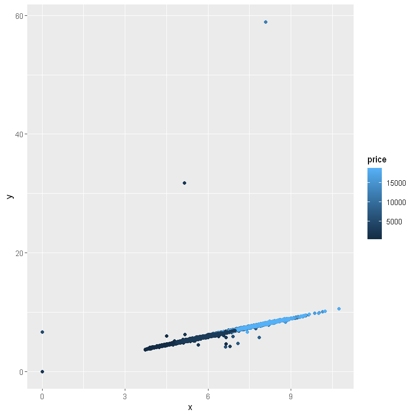

```r
qplot(x,y,data=diamonds,color=price)
```

```r
?mpg
```

```r
View(mpg)
```

A tibble: 234 × 11

| manufacturer <chr> | model <chr> | displ <dbl> | year <int> | cyl <int> | trans <chr> | drv <chr> | cty <int> | hwy <int> | fl <chr> | class <chr> |
| --- | --- | --- | --- | --- | --- | --- | --- | --- | --- | --- |
| audi | a4 | 1.8 | 1999 | 4 | auto(l5) | f | 18 | 29 | p | compact |
| audi | a4 | 1.8 | 1999 | 4 | manual(m5) | f | 21 | 29 | p | compact |
| audi | a4 | 2.0 | 2008 | 4 | manual(m6) | f | 20 | 31 | p | compact |
| audi | a4 | 2.0 | 2008 | 4 | auto(av) | f | 21 | 30 | p | compact |
| audi | a4 | 2.8 | 1999 | 6 | auto(l5) | f | 16 | 26 | p | compact |
| audi | a4 | 2.8 | 1999 | 6 | manual(m5) | f | 18 | 26 | p | compact |
| audi | a4 | 3.1 | 2008 | 6 | auto(av) | f | 18 | 27 | p | compact |
| audi | a4 quattro | 1.8 | 1999 | 4 | manual(m5) | 4 | 18 | 26 | p | compact |
| audi | a4 quattro | 1.8 | 1999 | 4 | auto(l5) | 4 | 16 | 25 | p | compact |
| audi | a4 quattro | 2.0 | 2008 | 4 | manual(m6) | 4 | 20 | 28 | p | compact |
| audi | a4 quattro | 2.0 | 2008 | 4 | auto(s6) | 4 | 19 | 27 | p | compact |
| audi | a4 quattro | 2.8 | 1999 | 6 | auto(l5) | 4 | 15 | 25 | p | compact |
| audi | a4 quattro | 2.8 | 1999 | 6 | manual(m5) | 4 | 17 | 25 | p | compact |
| audi | a4 quattro | 3.1 | 2008 | 6 | auto(s6) | 4 | 17 | 25 | p | compact |
| audi | a4 quattro | 3.1 | 2008 | 6 | manual(m6) | 4 | 15 | 25 | p | compact |
| audi | a6 quattro | 2.8 | 1999 | 6 | auto(l5) | 4 | 15 | 24 | p | midsize |
| audi | a6 quattro | 3.1 | 2008 | 6 | auto(s6) | 4 | 17 | 25 | p | midsize |
| audi | a6 quattro | 4.2 | 2008 | 8 | auto(s6) | 4 | 16 | 23 | p | midsize |
| chevrolet | c1500 suburban 2wd | 5.3 | 2008 | 8 | auto(l4) | r | 14 | 20 | r | suv |
| chevrolet | c1500 suburban 2wd | 5.3 | 2008 | 8 | auto(l4) | r | 11 | 15 | e | suv |
| chevrolet | c1500 suburban 2wd | 5.3 | 2008 | 8 | auto(l4) | r | 14 | 20 | r | suv |
| chevrolet | c1500 suburban 2wd | 5.7 | 1999 | 8 | auto(l4) | r | 13 | 17 | r | suv |
| chevrolet | c1500 suburban 2wd | 6.0 | 2008 | 8 | auto(l4) | r | 12 | 17 | r | suv |
| chevrolet | corvette | 5.7 | 1999 | 8 | manual(m6) | r | 16 | 26 | p | 2seater |
| chevrolet | corvette | 5.7 | 1999 | 8 | auto(l4) | r | 15 | 23 | p | 2seater |
| chevrolet | corvette | 6.2 | 2008 | 8 | manual(m6) | r | 16 | 26 | p | 2seater |
| chevrolet | corvette | 6.2 | 2008 | 8 | auto(s6) | r | 15 | 25 | p | 2seater |
| chevrolet | corvette | 7.0 | 2008 | 8 | manual(m6) | r | 15 | 24 | p | 2seater |
| chevrolet | k1500 tahoe 4wd | 5.3 | 2008 | 8 | auto(l4) | 4 | 14 | 19 | r | suv |
| chevrolet | k1500 tahoe 4wd | 5.3 | 2008 | 8 | auto(l4) | 4 | 11 | 14 | e | suv |
| ⋮ | ⋮ | ⋮ | ⋮ | ⋮ | ⋮ | ⋮ | ⋮ | ⋮ | ⋮ | ⋮ |
| toyota | toyota tacoma 4wd | 3.4 | 1999 | 6 | auto(l4) | 4 | 15 | 19 | r | pickup |
| toyota | toyota tacoma 4wd | 4.0 | 2008 | 6 | manual(m6) | 4 | 15 | 18 | r | pickup |
| toyota | toyota tacoma 4wd | 4.0 | 2008 | 6 | auto(l5) | 4 | 16 | 20 | r | pickup |
| volkswagen | gti | 2.0 | 1999 | 4 | manual(m5) | f | 21 | 29 | r | compact |
| volkswagen | gti | 2.0 | 1999 | 4 | auto(l4) | f | 19 | 26 | r | compact |
| volkswagen | gti | 2.0 | 2008 | 4 | manual(m6) | f | 21 | 29 | p | compact |
| volkswagen | gti | 2.0 | 2008 | 4 | auto(s6) | f | 22 | 29 | p | compact |
| volkswagen | gti | 2.8 | 1999 | 6 | manual(m5) | f | 17 | 24 | r | compact |
| volkswagen | jetta | 1.9 | 1999 | 4 | manual(m5) | f | 33 | 44 | d | compact |
| volkswagen | jetta | 2.0 | 1999 | 4 | manual(m5) | f | 21 | 29 | r | compact |
| volkswagen | jetta | 2.0 | 1999 | 4 | auto(l4) | f | 19 | 26 | r | compact |
| volkswagen | jetta | 2.0 | 2008 | 4 | auto(s6) | f | 22 | 29 | p | compact |
| volkswagen | jetta | 2.0 | 2008 | 4 | manual(m6) | f | 21 | 29 | p | compact |
| volkswagen | jetta | 2.5 | 2008 | 5 | auto(s6) | f | 21 | 29 | r | compact |
| volkswagen | jetta | 2.5 | 2008 | 5 | manual(m5) | f | 21 | 29 | r | compact |
| volkswagen | jetta | 2.8 | 1999 | 6 | auto(l4) | f | 16 | 23 | r | compact |
| volkswagen | jetta | 2.8 | 1999 | 6 | manual(m5) | f | 17 | 24 | r | compact |
| volkswagen | new beetle | 1.9 | 1999 | 4 | manual(m5) | f | 35 | 44 | d | subcompact |
| volkswagen | new beetle | 1.9 | 1999 | 4 | auto(l4) | f | 29 | 41 | d | subcompact |
| volkswagen | new beetle | 2.0 | 1999 | 4 | manual(m5) | f | 21 | 29 | r | subcompact |
| volkswagen | new beetle | 2.0 | 1999 | 4 | auto(l4) | f | 19 | 26 | r | subcompact |
| volkswagen | new beetle | 2.5 | 2008 | 5 | manual(m5) | f | 20 | 28 | r | subcompact |
| volkswagen | new beetle | 2.5 | 2008 | 5 | auto(s6) | f | 20 | 29 | r | subcompact |
| volkswagen | passat | 1.8 | 1999 | 4 | manual(m5) | f | 21 | 29 | p | midsize |
| volkswagen | passat | 1.8 | 1999 | 4 | auto(l5) | f | 18 | 29 | p | midsize |
| volkswagen | passat | 2.0 | 2008 | 4 | auto(s6) | f | 19 | 28 | p | midsize |
| volkswagen | passat | 2.0 | 2008 | 4 | manual(m6) | f | 21 | 29 | p | midsize |
| volkswagen | passat | 2.8 | 1999 | 6 | auto(l5) | f | 16 | 26 | p | midsize |
| volkswagen | passat | 2.8 | 1999 | 6 | manual(m5) | f | 18 | 26 | p | midsize |
| volkswagen | passat | 3.6 | 2008 | 6 | auto(s6) | f | 17 | 26 | p | midsize |

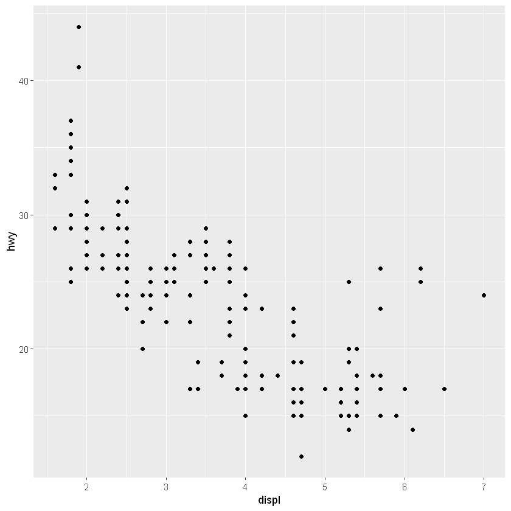

```r
qplot(displ,hwy,data=mpg)
```

## Aesthetics

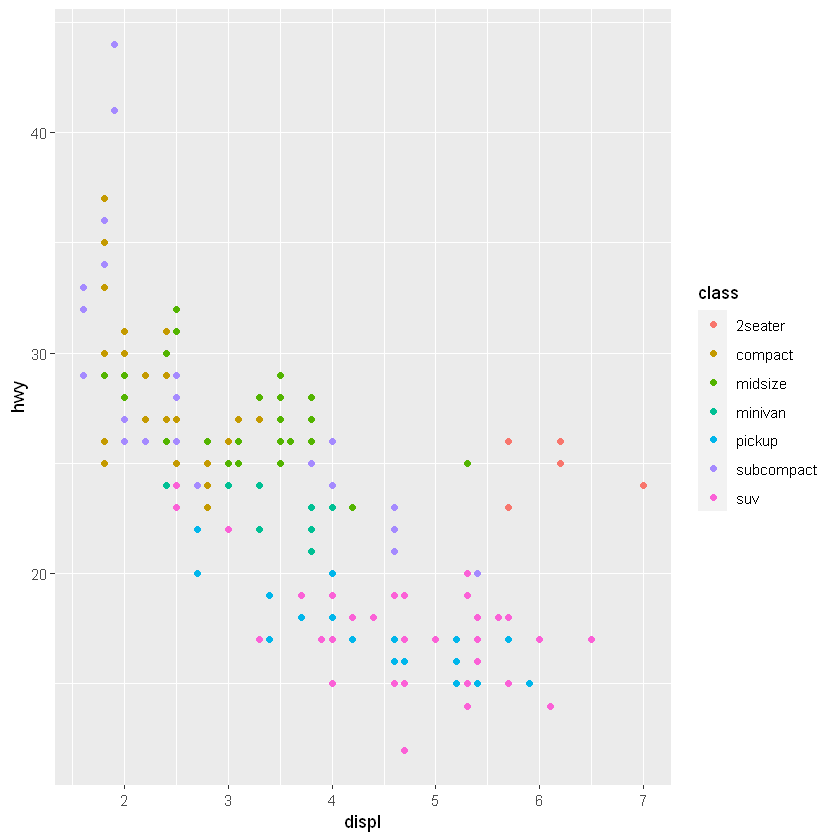

```r
qplot(displ,hwy,data=mpg,color=class)
```

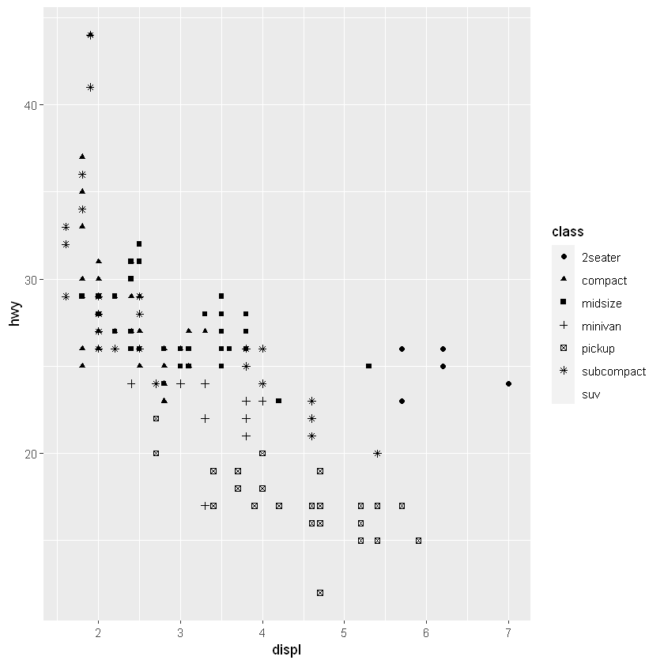

```r
qplot(displ,hwy,data=mpg,shape=class)
```

## Facetting

Smaller plots that display different subsets of the data. Also useful for exploring conditional relationships. Useful for large data.

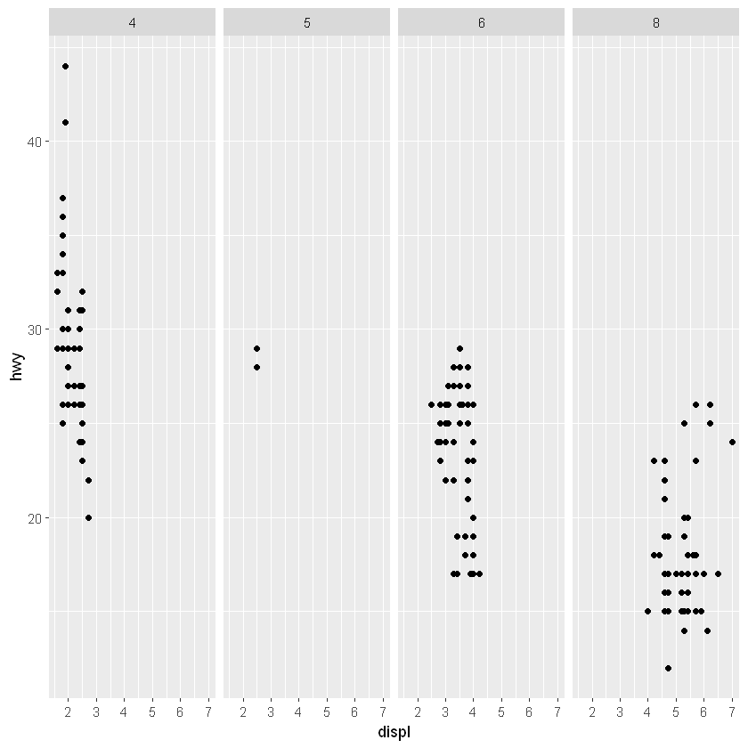

```r
qplot(displ,hwy,data=mpg)+facet_grid(. ~ cyl)
```

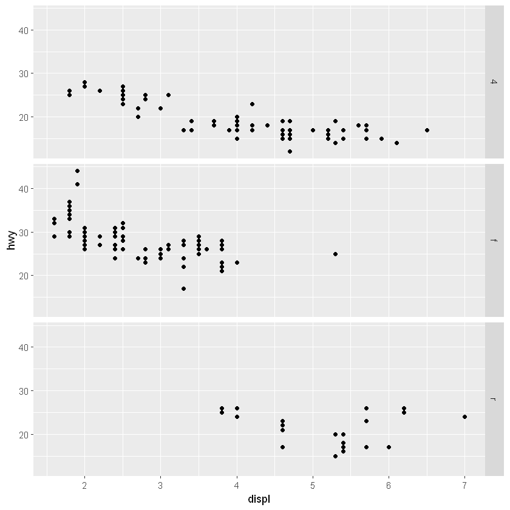

```r
qplot(displ,hwy,data=mpg)+facet_grid(drv ~ .)
```

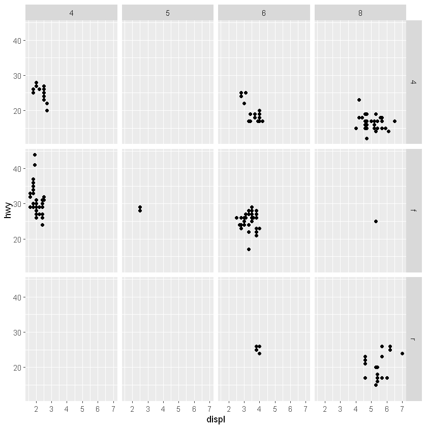

```r
qplot(displ,hwy,data=mpg)+facet_grid(drv ~ cyl)
```

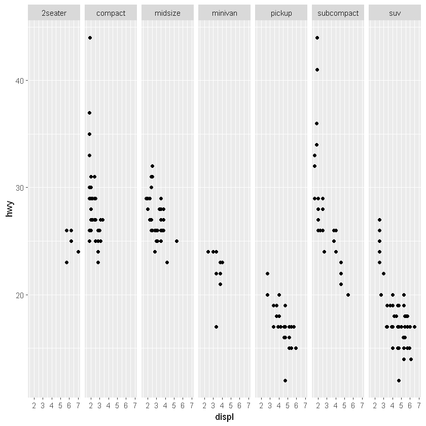

```r
qplot(displ,hwy,data=mpg)+facet_grid( ~ class)
```

## Geoms

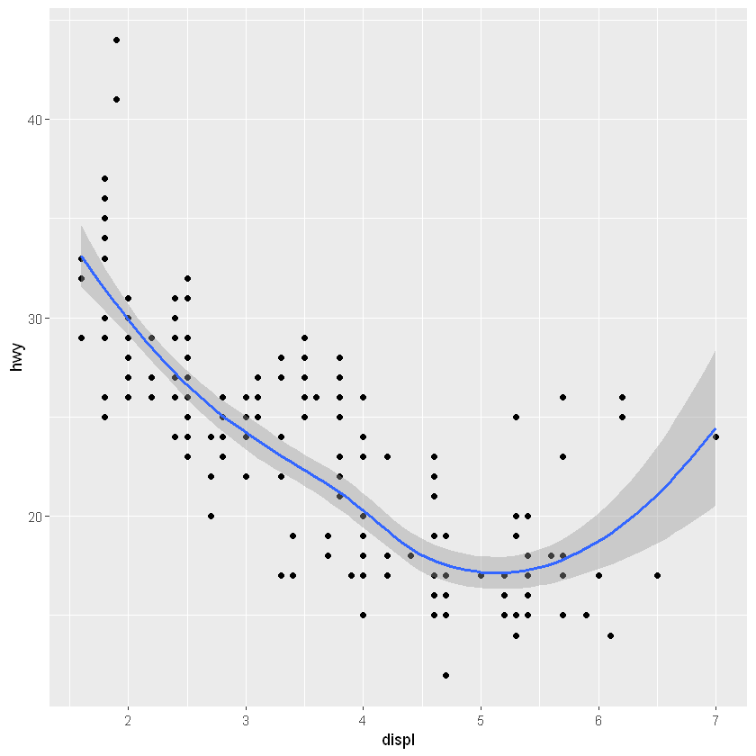

```r
qplot(displ,hwy,data=mpg,geom=c("point","smooth"))
```

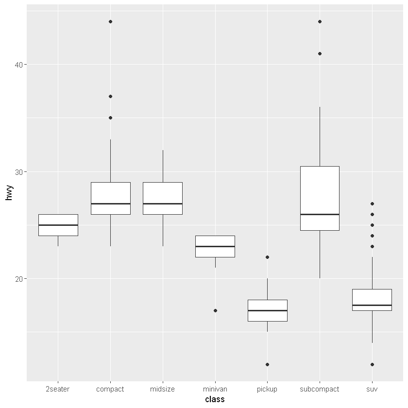

```r
qplot(class,hwy,data=mpg,geom='boxplot')
```

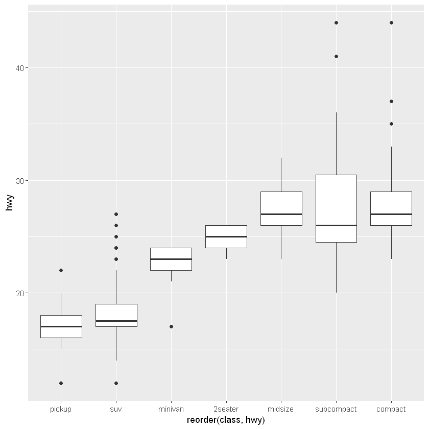

```r
qplot(reorder(class,hwy),hwy,data=mpg,geom='boxplot') # Reorder is based on mean
```

## Position Adjustments

### Histogram

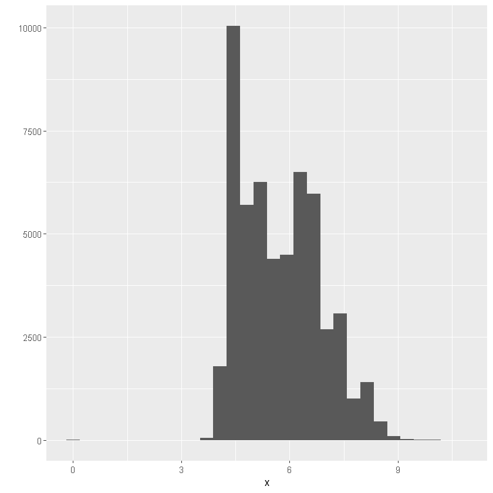

```r
qplot(x,data=diamonds)
```

### Bar Chart

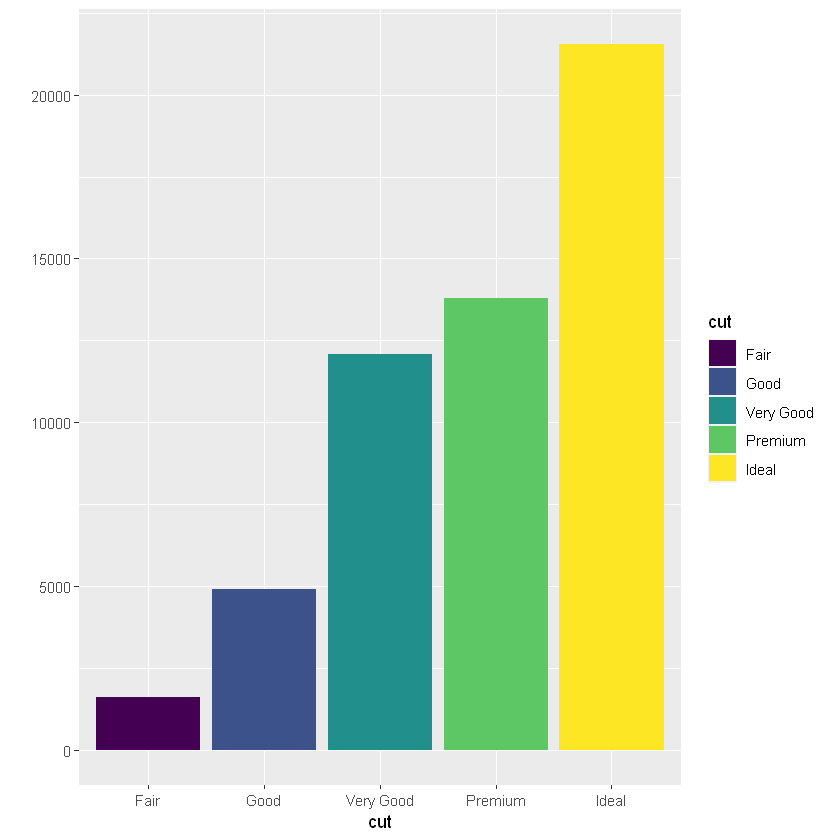

```r
qplot(cut,data=diamonds,geom='bar',fill=cut)
```

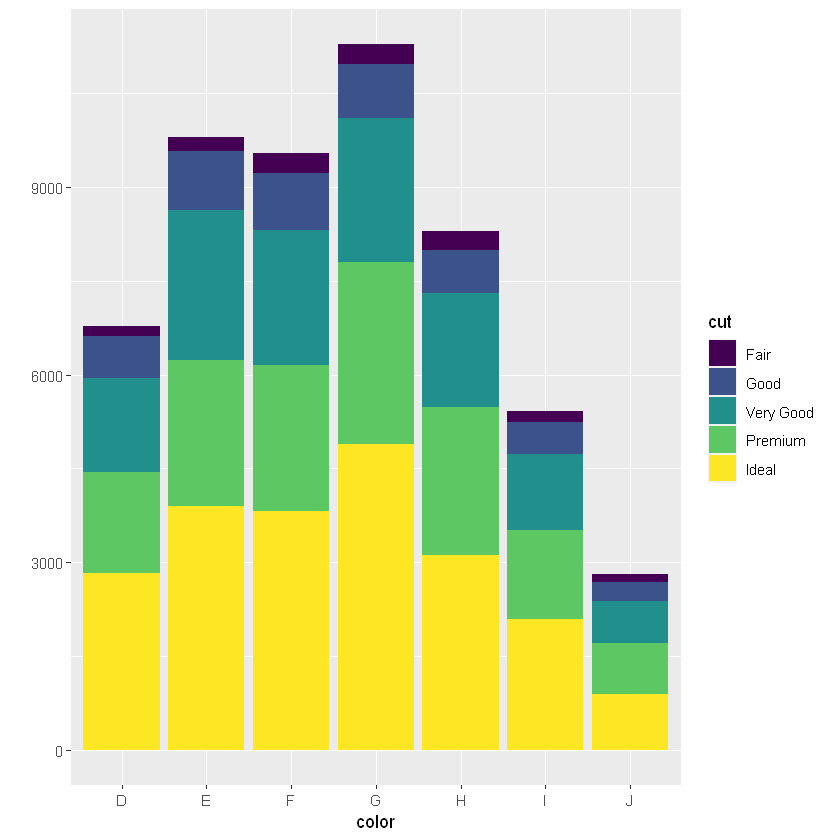

```r
qplot(color,data=diamonds,geom='bar',fill=cut)
```

## Visualizing Distributions

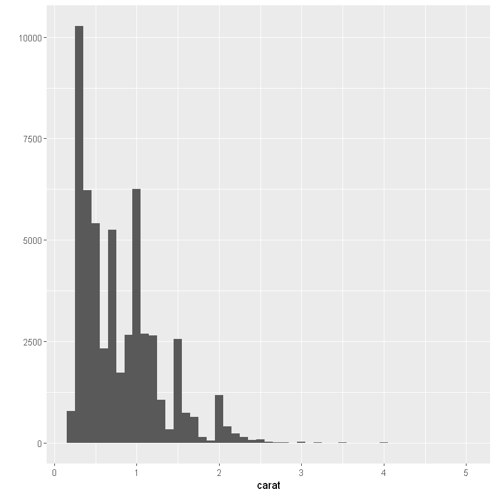

```r
qplot(carat,data=diamonds,binwidth=0.1)
```

## Adding Zoom

```r
zoom <- coord_cartesian(xlim=c(50,70))
```

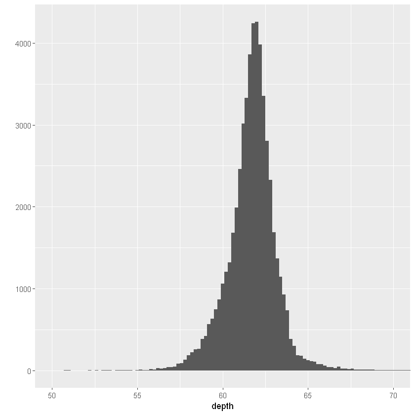

```r
qplot(depth,data=diamonds,binwidth=0.2)+zoom
```

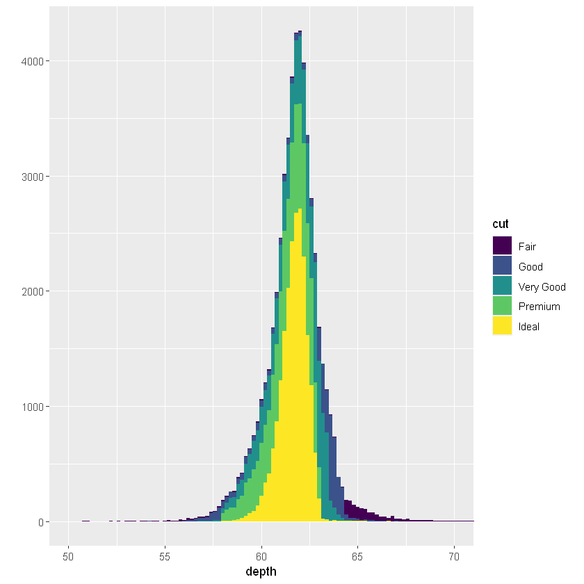

```r
qplot(depth,data=diamonds,binwidth=0.2,fill=cut)+zoom
```

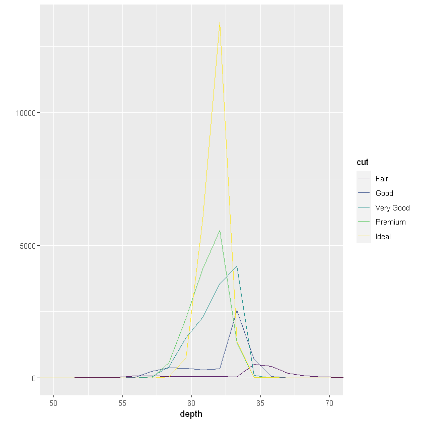

```r
qplot(depth,data=diamonds,geom="freqpoly", color=cut)+zoom
```

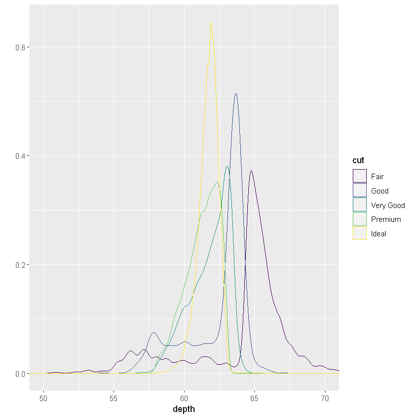

```r
qplot(depth,data=diamonds,geom="density", color=cut)+zoom
```

## Visalizing Big Data

[figure not shown]

```r
# install.packages('hexbin')
qplot(carat,price,data=diamonds,geom='hex')
```

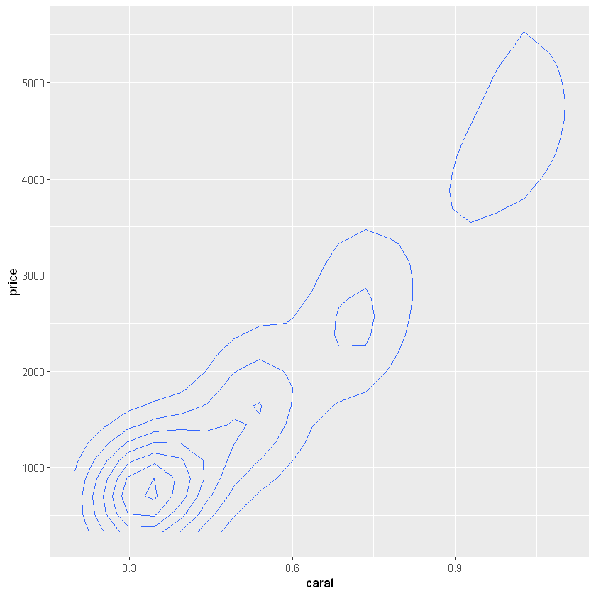

```r
qplot(carat,price,data=diamonds,geom='density2d')
```

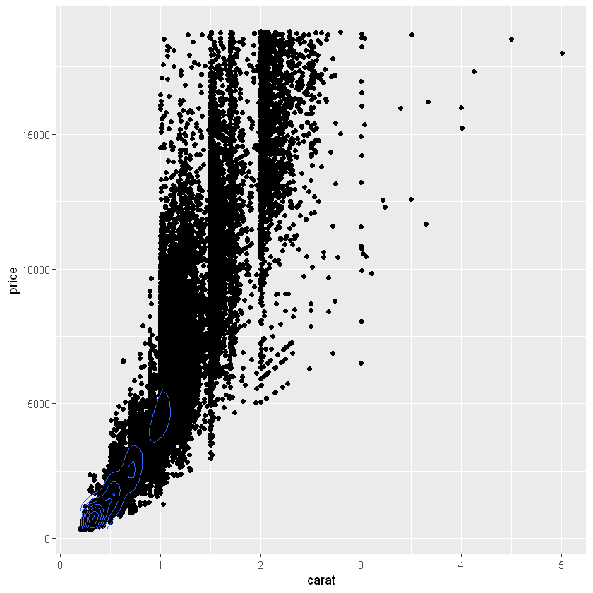

```r
qplot(carat,price,data=diamonds,geom=c('point','density2d'))
```

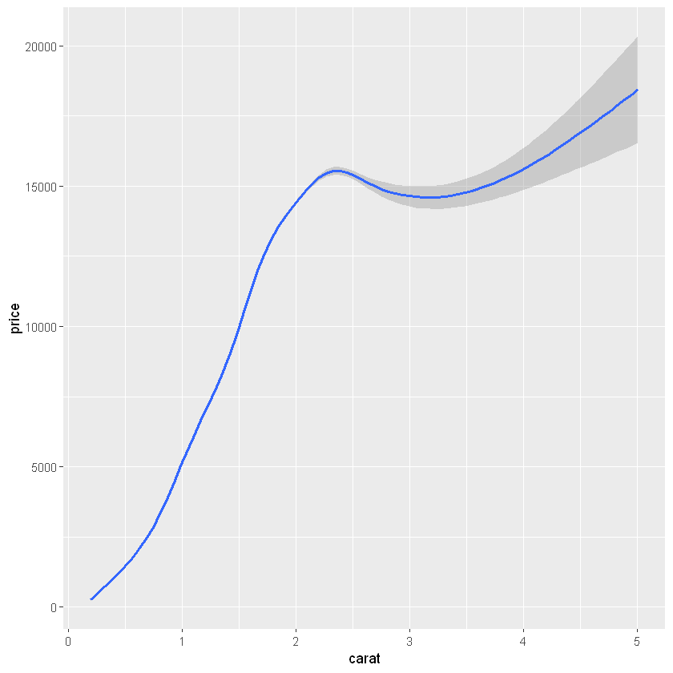

```r
qplot(carat,price,data=diamonds,geom='smooth')
```